# U.S. City Urban Forests

Urban trees play a vital role in city infrastructure for several reasons. They improve air quality and help mitigate climate change by filtering pollutants and storing carbon. Trees also aid in stormwater management and are key to reducing the urban heat island effect. This project seeks to better understand the behavior and health of urban forests, with the goal of improving how resources, such as city maintenance and planning, are allocated. A deeper understanding can also inform more effective environmental policies and support community initiatives in underserved neighborhoods. Urban trees are indicators of environmental health and social equity. When we understand urban forests, we are better equipped to manage, protect, and plan for them.

```python
# basic imports
import pandas as pd
import numpy as np
import seaborn as sns
import matplotlib.pyplot as plt
import os
import splot

# scikit learn
from sklearn.preprocessing import LabelEncoder
from sklearn.model_selection import train_test_split, cross_val_score
from sklearn.linear_model import LinearRegression, Lasso, Ridge, LogisticRegression
from sklearn.metrics import r2_score, mean_squared_error, accuracy_score, classification_report
from sklearn.cluster import KMeans
from sklearn.ensemble import RandomForestClassifier, VotingClassifier
from sklearn.tree import DecisionTreeClassifier
from sklearn.neighbors import KNeighborsClassifier, KNeighborsRegressor, NearestNeighbors
from sklearn.metrics import confusion_matrix, ConfusionMatrixDisplay

from pygam import LinearGAM, LogisticGAM, s, f
import statsmodels.api as sm
import geopandas as gpd
from esda.moran import Moran, Moran_Local
from libpysal.weights import KNN
from shapely.geometry import Point
```

## Loading/Cleaning Data

This dataset from Dryad consists of 5,660,237 trees from 63 of the largest 250 US cities (and Ontario). Although all files are formatted the same, the select features inventoried varied from city to city... leading to lots of missing values upon compiling on cities into one dataframe. The concept was to clean by building two denser inventories, based on the response variables height and health respectively. In the last section, we will look at the subset of data which contains all variables of interest, and is essentially restricted to the state of Hawaii.

Main Issues:

- some cities dense in numerical and spatial (height/diameter, location)
- others in simple inventory (species, health)
- random misentries (ex: recorded 0s instead of NaN)
- the use of common name and scientific name as means of identification (can be many to one)

```python
# ALL CITIES

citytrees = pd.read_csv('/Users/millerchristen/Desktop/STAT 531/all_cities.csv')
citytrees.isna().sum().sort_values() # out of 5660264

citytrees = citytrees.drop(columns = ['percent_population', 'tree_ID', 'definition', 'column_name',
                                      'retired_date', 'district', 'ward', 'location_name', 'planted_date', 'neighborhood', 'overhead_utility'])
citytrees = citytrees.dropna(subset=['latitude_coordinate', 'longitude_coordinate'])
# citytrees.nunique()
```

```python
citytrees.head()
```

|  | most_recent_observation | most_recent_observation_type | common_name | scientific_name | city | state | longitude_coordinate | latitude_coordinate | location_type | address | diameter_breast_height_CM | condition | height_M | native | height_binned_M | diameter_breast_height_binned_CM | greater_metro | city_ID | zipcode |
| --- | --- | --- | --- | --- | --- | --- | --- | --- | --- | --- | --- | --- | --- | --- | --- | --- | --- | --- | --- |
| 0 | NaN | inventory_date | NaN | NaN | Cedarburg | Wisconsin | -87.997964 | 43.299162 | no_info | N67W7125 Cleveland Street | NaN | NaN | NaN | no_info | NaN | NaN | Milwaukee | NaN | NaN |
| 1 | NaN | inventory_date | NaN | NaN | Cedarburg | Wisconsin | -88.003973 | 43.300466 | no_info | N70W7567 Bridge Road | NaN | NaN | NaN | no_info | NaN | NaN | Milwaukee | NaN | NaN |
| 2 | NaN | inventory_date | NaN | NaN | Cedarburg | Wisconsin | -88.003586 | 43.298355 | no_info | W75 N624 North Wauwatosa Road | NaN | NaN | NaN | no_info | NaN | NaN | Milwaukee | NaN | NaN |
| 3 | NaN | inventory_date | NaN | NaN | Cedarburg | Wisconsin | -88.003586 | 43.298355 | no_info | W75 N624 North Wauwatosa Road | NaN | NaN | NaN | no_info | NaN | NaN | Milwaukee | NaN | NaN |
| 4 | NaN | inventory_date | NaN | NaN | Cedarburg | Wisconsin | -88.003586 | 43.298355 | no_info | W75 N624 North Wauwatosa Road | NaN | NaN | NaN | no_info | NaN | NaN | Milwaukee | NaN | NaN |

```python
citytrees.columns.tolist()
```

```
['most_recent_observation',
 'most_recent_observation_type',
 'common_name',
 'scientific_name',
 'city',
 'state',
 'longitude_coordinate',
 'latitude_coordinate',
 'location_type',
 'address',
 'diameter_breast_height_CM',
 'condition',
 'height_M',
 'native',
 'height_binned_M',
 'diameter_breast_height_binned_CM',
 'greater_metro',
 'city_ID',
 'zipcode']
```

```python
# LIST 63 CITIES

folder_path = "/Users/millerchristen/Desktop/STAT 531/TREES"

city_names = []

for filename in os.listdir(folder_path):
    if filename.endswith(".csv"):
        city = filename.split("_")[0]
        city_names.append(city)

# Optional: remove duplicates and sort
city_names = sorted(set(city_names))

print(city_names)
len(city_names)
```

```
['Albuquerque', 'Anaheim', 'Arlington', 'Atlanta', 'AuroraCO', 'Austin', 'Baltimore', 'Boston', 'Buffalo', 'CapeCoral', 'ColoradoSprings', 'Columbus', 'Dallas', 'Denver', 'DesMoines', 'Detroit', 'Durham', 'Fresno', 'GardenGrove', 'GrandRapids', 'Greensboro', 'Honolulu', 'Houston', 'HuntingtonBeach',…
```

```
63
```

```python
# PEEP CITY COLUMNS

input_folder = "/Users/millerchristen/Desktop/STAT 531/TREES"

# make dictionary
for filename in os.listdir(input_folder)[:5]: # only show first 3 for html
    if filename.endswith(".csv"):
        file_path = os.path.join(input_folder, filename)
        df = pd.read_csv(file_path)

        # file details
        file_length = len(df)
        columns = df.columns.tolist()
        missing_values = df.isna().sum()

        print("\n")
        print(f"City: {filename}")
        print(f"Rows: {file_length}")
        print("Columns:")
        for col, missing in missing_values.items():
            print(f"   - {col}: {missing} missing values")
```

```
City: Arlington_Final_2022-06-18.csv
Rows: 14827
Columns:
   - planted_date: 1591 missing values
   - retired_date: 12637 missing values
   - scientific_name: 154 missing values
   - city: 0 missing values
   - state: 0 missing values
   - longitude_coordinate: 0 missing values
   - latitude_coordinate: 0 missing values
   - native: 0 missing values
   - greater_metro: 0 missing values


City: Miami_Final_2022-06-18.csv
Rows: 732
Columns:
   - common_name: 0 missing values
   - scientific_name: 1 missing values
   - city: 0 missing values
   - state: 0 missing values
   - diameter_breast_height_CM: 0 missing values
   - condition: 0 missing values
   - native: 0 missing values
   - diameter_breast_height_binned_CM: 0 missing values
   - greater_metro: 0 missing values


City: Austin_Final_2022-06-18.csv
Rows: 7295
Columns:
   - city_ID: 0 missing values
   - common_name: 0 missing values
   - scientific_name: 1320 missing values
   - city: 0 missing values
   - state: 0 missing values
   - longitude_coordinate: 0 missing values
   - latitude_coordinate: 0 missing values
   - address: 0 missing values
   - location_name: 6873 missing values
   - diameter_breast_height_CM: 0 missing values
   - condition: 1395 missing values
   - height_M: 0 missing values
   - native: 0 missing values
   - height_binned_M: 1298 missing values
   - diameter_breast_height_binned_CM: 1222 missing values
   - greater_metro: 0 missing values
```

```python
# LOADING A FEW CITIES

atlanta = pd.read_csv('TREES/Atlanta_Final_2022-06-18.csv') # Atlanta
aurora = pd.read_csv('TREES/AuroraCO_Final_2022-06-18.csv') # Aurora
baltimore = pd.read_csv('TREES/Baltimore_Final_2022-06-18.csv') # Baltimore
boston = pd.read_csv('TREES/Boston_Final_2022-06-18.csv') # Boston
colsprings = pd.read_csv('TREES/ColoradoSprings_Final_2022-06-18.csv') # Colorado Springs
columbus = pd.read_csv('TREES/Columbus_Final_2022-06-18.csv') # Columbus
dallas = pd.read_csv('TREES/Dallas_Final_2022-06-18.csv') # Dallas
denver = pd.read_csv('TREES/Denver_Final_2022-06-18.csv') # Denver
detroit = pd.read_csv('TREES/Detroit_Final_2022-06-18.csv') # Detroit
newyork = pd.read_csv('TREES/NewYork_Final_2022-06-18.csv') # New York
rochester = pd.read_csv('TREES/Rochester_Final_2022-06-18.csv') # Rochester
seattle = pd.read_csv('TREES/Seattle_Final_2022-06-18.csv') # Seattle
```

```python
# CLEAN TREE HEIGHT (SUBSET)

treeheight = citytrees.dropna(subset=["height_M"])
treeheight.isna().sum() # out of 709,143

# subset: 563,736 (253,692 with condition)
treeheight = citytrees[['height_M','diameter_breast_height_CM', 'native',
            'state','longitude_coordinate','latitude_coordinate', 'scientific_name']].dropna()
```

```python
# CLEAN TREE CONDITION (SUBSET)

treecondition = citytrees.dropna(subset=["condition"])
treecondition.isna().sum() # out of 2,621,737

# subset: 1,972,819 (2,392,903 without diameter)
treecondition = citytrees[['condition', 'native', 'diameter_breast_height_CM',
                'city','state','longitude_coordinate','latitude_coordinate', 'scientific_name']].dropna()
```

To look into clear outliers present on the diameter/height plot. Do they match species distribution? Can they be assumed mistake entries (height 0 instead of NaN, swapped diameter and height, misidentification, etc.)?

A few example index rows of concern in tree height subset:

Hawaii

- 3545471, 3538074, 3537040 (Cocos nucifera)
- 3545472, 3534629 (Casuarina equisetifolia)
- 3545473 (Cassia nealiae)

|  | height_M | diameter_breast_height_CM | native | state | longitude_coordinate | latitude_coordinate | scientific_name |
| --- | --- | --- | --- | --- | --- | --- | --- |
| 3534629 | 2401.57488 | 20.32 | introduced | Hawaii | -157.726946 | 21.396801 | Casuarina equisetifolia |
| 3537040 | 9931.10268 | 27.94 | introduced | Hawaii | -157.755134 | 21.406924 | Cocos nucifera |
| 3538074 | 2526.24680 | 30.48 | introduced | Hawaii | -157.728323 | 21.398229 | Cocos nucifera |
| 3545471 | 180.44620 | 2580.64 | introduced | Hawaii | -157.753671 | 21.408566 | Cocos nucifera |
| 3545472 | 262.46720 | 3314.70 | introduced | Hawaii | -157.723804 | 21.395790 | Casuarina equisetifolia |
| 3545473 | 82.02100 | 7188.20 | no_info | Hawaii | -157.845238 | 21.288721 | Cassia nealiae |
| 3876536 | 144.35696 | 1132.84 | introduced | California | -121.924547 | 37.343222 | Schinus molle |
| 3916040 | 2293.30716 | 43.18 | introduced | California | -121.830487 | 37.346995 | Washingtonia robusta |
| 3921281 | 6299.21280 | 33.02 | introduced | California | -121.848587 | 37.364415 | Zelkova serrata |
| 3929449 | 0.00000 | 5852.16 | introduced | California | -121.948157 | 37.337415 | Ginkgo biloba |
| 3957679 | 7217.84800 | 45.72 | introduced | California | -121.870777 | 37.400285 | Melaleuca quinquenervia |
| 3963798 | 9192.91368 | 25.40 | introduced | California | -121.843237 | 37.313015 | Fraxinus angustifolia |
| 3970095 | 6620.73512 | 20.32 | introduced | California | -121.910447 | 37.265475 | Pistacia chinensis |
| 3970209 | 6607.61176 | 20.32 | introduced | California | -121.908837 | 37.263465 | Liquidambar styraciflua |
| 3982733 | 3861.54868 | 12.70 | introduced | California | -121.926177 | 37.278685 | Tristaniopsis laurina |
| 3987028 | 2887.13920 | 55.88 | introduced | California | -121.901117 | 37.316765 | Washingtonia robusta |
| 3990366 | 2887.13920 | 48.26 | introduced | California | -121.899777 | 37.314305 | Washingtonia robusta |
| 3995085 | 2004.59324 | 40.64 | introduced | California | -121.898907 | 37.316215 | Washingtonia robusta |
| 3997472 | 8943.56984 | 66.04 | no_info | California | -121.854797 | 37.399905 | Schinus terebinthifolius |
| 4006623 | 2181.75860 | 901.70 | naturally_occurring | California | -121.878837 | 37.337615 | Washingtonia filifera |
| 4011806 | 2913.38592 | 45.72 | introduced | California | -121.892017 | 37.341815 | Washingtonia robusta |
| 4019054 | 2063.64836 | 30.48 | introduced | California | -121.854217 | 37.261335 | Magnolia grandiflora |

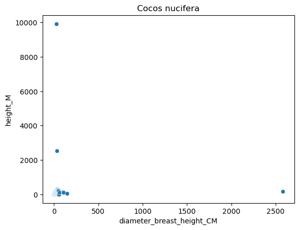

```python
# species distribution
sns.scatterplot(data=citytrees[citytrees["scientific_name"] == "Cocos nucifera"],
                 y="height_M",
                 x="diameter_breast_height_CM").set_title('Cocos nucifera')

# filter to find big outliers
treeheight[
    (treeheight["height_M"] > 2000) |
    (treeheight["diameter_breast_height_CM"] > 1000)
]
```

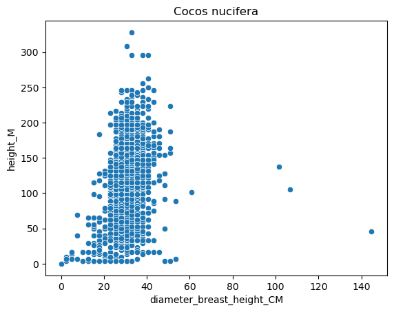

```python
#treeheight = pd.read_csv('treeheight.csv')
treeheight.drop(index=[3929449, 3545471, 3538074, 3537040, 3545472, 3534629, 3545473], inplace=True)

sns.scatterplot(data=treeheight[treeheight["scientific_name"] == "Cocos nucifera"],
                y="height_M",
                x="diameter_breast_height_CM").set_title('Cocos nucifera')
```

## Data Visualizations

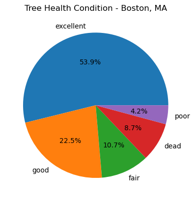

```python
# Tree Health Pie - Boston
plt.figure()
boston['condition'].value_counts().plot(kind='pie', autopct='%1.1f%%')
plt.ylabel("")
plt.title("Tree Health Condition - Boston, MA")
plt.show()
```

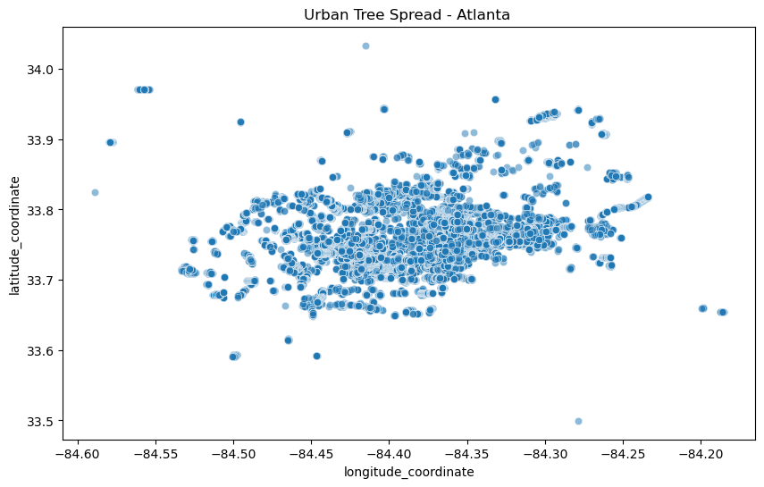

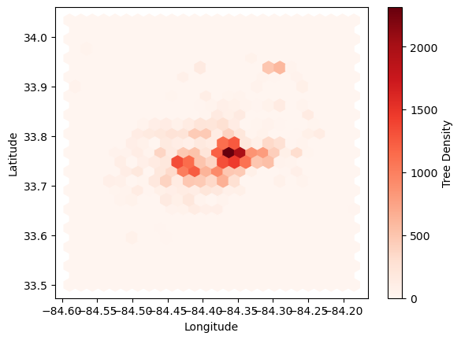

```python
# Geospatial Dist. - Atlanta
plt.figure(figsize=(10, 6))
sns.scatterplot(x = atlanta['longitude_coordinate'],
                y = atlanta['latitude_coordinate'], alpha=0.5)
plt.title("Urban Tree Spread - Atlanta ")
plt.show()

# Heatplot
plt.hexbin(atlanta['longitude_coordinate'], atlanta['latitude_coordinate'], cmap='Reds', gridsize=25)
plt.xlabel("Longitude")
plt.ylabel("Latitude")
plt.colorbar(label="Tree Density")
plt.show()
```

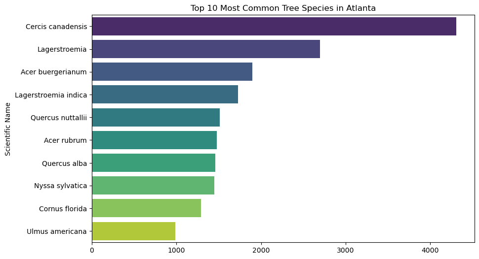

```python
# Most Common Species - Atlanta
plt.figure(figsize=(10, 6))
sns.countplot(y = atlanta['scientific_name'],
              order = atlanta['scientific_name'].value_counts().index[:10], palette = "viridis")
plt.xlabel("")
plt.ylabel("Scientific Name")
plt.title("Top 10 Most Common Tree Species in Atlanta")
plt.show()
```

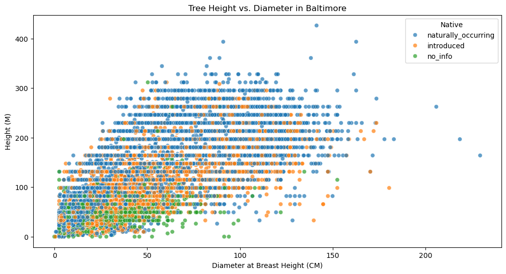

```python
# Native Trees - Baltimore
plt.figure(figsize=(12, 6))
sns.scatterplot(x = baltimore['diameter_breast_height_CM'],
                y = baltimore['height_M'], hue=baltimore['native'], alpha=0.7)
plt.xlabel("Diameter at Breast Height (CM)")
plt.ylabel("Height (M)")
plt.title("Tree Height vs. Diameter in Baltimore")
plt.legend(title="Native")
plt.show()
```

```python
# Correlation Heatmap
# corr_matrix = citytrees.corr(numeric_only=True)
# sns.heatmap(corr_matrix, annot=True, cmap = 'twilight_shifted')
# plt.show()
```

## Tree Height v. Diameter

This section focuses on filtered trees with valid measurements for height (a subset listed in data loading/cleaning section). Species were shown to differ too greatly in height distribution, leading to modeling heigh for each individual species.

- Model height as a function of diameter, species, nativity, and location
- Use of OLS (all species)
- Use of Linear, Ridge, and LASSO regression (individual species height)
- Use of LASSO feature selection

These regressions had approximately the same evaluation, yielding approximately same R^2 and RMSE, an indication of low/no multicollinearity and robustness. Most species selected same features. Still seeing some potential misentries...

```
                            OLS Regression Results
==============================================================================
Dep. Variable:               height_M   R-squared:                       0.412
Model:                            OLS   Adj. R-squared:                  0.412
Method:                 Least Squares   F-statistic:                 6.595e+04
Date:                Mon, 31 Mar 2025   Prob (F-statistic):               0.00
Time:                        13:41:51   Log-Likelihood:            -2.9858e+06
No. Observations:              563729   AIC:                         5.972e+06
Df Residuals:                  563722   BIC:                         5.972e+06
Df Model:                           6
Covariance Type:            nonrobust
=============================================================================================
                                coef    std err          t      P>|t|      [0.025      0.975]
---------------------------------------------------------------------------------------------
const                      -122.8670      0.940   -130.720      0.000    -124.709    -121.025
diameter_breast_height_CM     1.6424      0.003    598.855      0.000       1.637       1.648
native                       -3.9521      0.106    -37.349      0.000      -4.160      -3.745
state                         6.2418      0.041    151.185      0.000       6.161       6.323
longitude_coordinate         -0.4489      0.004   -106.521      0.000      -0.457      -0.441
latitude_coordinate           2.8884      0.018    161.771      0.000       2.853       2.923
scientific_name               0.0057      0.000     25.223      0.000       0.005       0.006
==============================================================================
Omnibus:                  1695189.957   Durbin-Watson:                   1.376
Prob(Omnibus):                  0.000   Jarque-Bera (JB):    1110203683090.586
Skew:                          43.218   Prob(JB):                         0.00
Kurtosis:                    6877.442   Cond. No.                     9.61e+03
==============================================================================

Notes:
[1] Standard Errors assume that the covariance matrix of the errors is correctly specified.
[2] The condition number is large, 9.61e+03. This might indicate that there are
strong multicollinearity or other numerical problems.
```

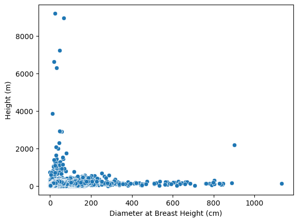

```python
### All Species Together ###

# Height v. Diameter
sns.scatterplot(data=treeheight, y="height_M",
                x="diameter_breast_height_CM").set(ylabel='Height (m)', xlabel='Diameter at Breast Height (cm)')

treeheight_encoded = treeheight.copy()

le = LabelEncoder()
cat_cols = treeheight_encoded.select_dtypes(include=['object']).columns
for col in cat_cols:
    treeheight_encoded[col] = le.fit_transform(treeheight_encoded[col])

# OLS
X = treeheight_encoded.drop(columns=['height_M'])
X_ols = sm.add_constant(X)
y = treeheight_encoded['height_M']
regmodel = sm.OLS(y, X_ols).fit()
print(regmodel.summary())
```

```
Species: Ulmus americana (n=2688)
Linear Regression R²: 0.647, RMSE: 34.300
Ridge Regression R²: 0.645, RMSE: 34.387
LASSO Regression R²: 0.639, RMSE: 34.663
Number of selected features: 4
Selected features: ['diameter_breast_height_CM', 'state', 'longitude_coordinate', 'latitude_coordinate']
```

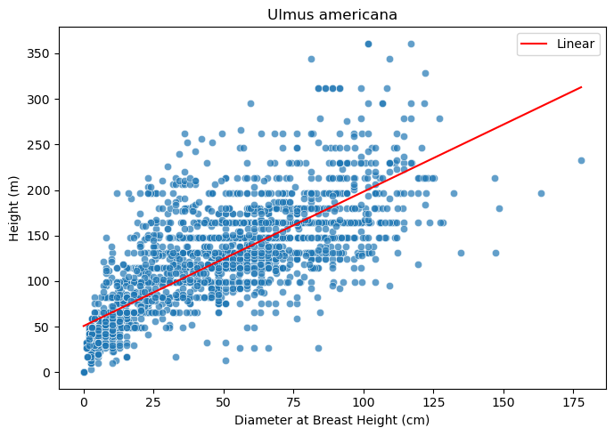

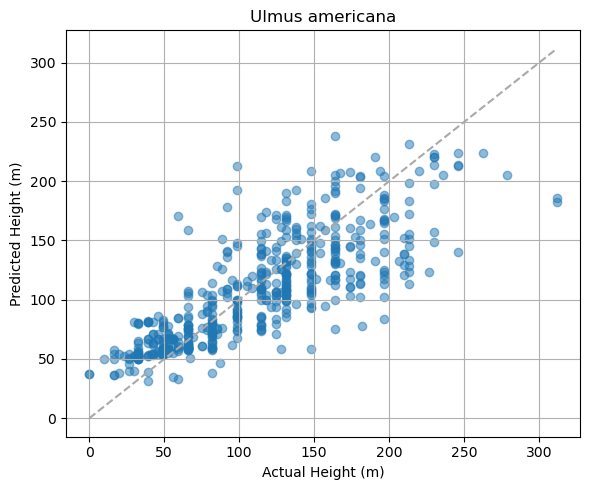

```
Species: Quercus stellata (n=728)
Linear Regression R²: 0.619, RMSE: 28.973
Ridge Regression R²: 0.600, RMSE: 29.695
LASSO Regression R²: 0.580, RMSE: 30.433
Number of selected features: 4
Selected features: ['diameter_breast_height_CM', 'state', 'longitude_coordinate', 'latitude_coordinate']
```

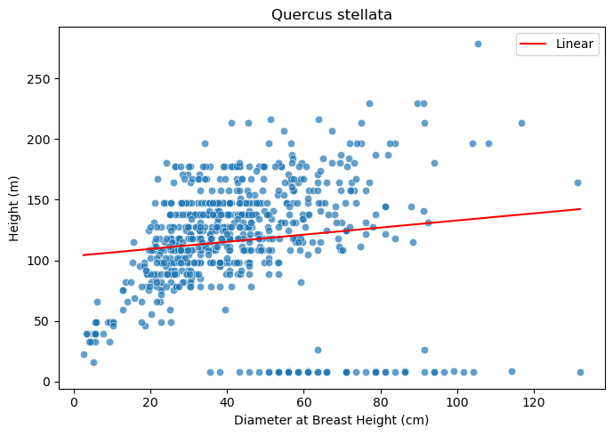

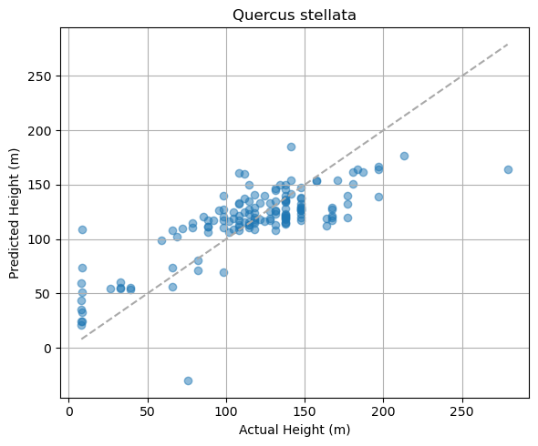

```python
### Species by Species - Linear ###
species = treeheight['scientific_name'].unique()
le = LabelEncoder()

# Regression
def species_reg(name):
    speciesdf = treeheight[treeheight['scientific_name'] == name].copy()

    # skip species with too few points
    if len(speciesdf) < 30:
        print(f"Not enough data (n={len(speciesdf)})")
        return

    # encode categorical
    cat_cols = speciesdf.select_dtypes(include=['object']).columns
    for col in cat_cols:
        speciesdf[col] = le.fit_transform(speciesdf[col])

    print(f"\nSpecies: {name} (n={len(speciesdf)})")

    # split data
    X = speciesdf.drop(columns=['height_M'])
    y = speciesdf['height_M']
    trainX, testX, trainy, testy = train_test_split(X, y, test_size=0.2, random_state=42)

    # Linear Regression
    lr = LinearRegression()
    lr.fit(trainX, trainy)
    y_pred_lr = lr.predict(testX)
    r2_lr = r2_score(testy, y_pred_lr)
    rmse_lr = np.sqrt(mean_squared_error(testy, y_pred_lr))
    print(f"Linear Regression R²: {r2_lr:.3f}, RMSE: {rmse_lr:.3f}")

    # Ridge Regression
    rid = Ridge(alpha=5.0) # bumped up from 1.0
    rid.fit(trainX, trainy)
    y_pred_rid = rid.predict(testX)
    r2_rid = r2_score(testy, y_pred_rid)
    rmse_rid = np.sqrt(mean_squared_error(testy, y_pred_rid))
    print(f"Ridge Regression R²: {r2_rid:.3f}, RMSE: {rmse_rid:.3f}")

    # LASSO Regression
    lasso = Lasso(alpha=1.0)
    lasso.fit(trainX, trainy)
    y_pred_lasso = lasso.predict(testX)
    r2_lasso = r2_score(testy, y_pred_lasso)
    rmse_lasso = np.sqrt(mean_squared_error(testy, y_pred_lasso))
    print(f"LASSO Regression R²: {r2_lasso:.3f}, RMSE: {rmse_lasso:.3f}")

    # LASSO Feature Selection
    feature_coef = pd.Series(lasso.coef_, index=X.columns)
    selected_features = feature_coef[feature_coef != 0].index
    print(f"Number of selected features: {len(selected_features)}")
    print(f"Selected features: {list(selected_features)}")

    # scatterplot
    plt.figure(figsize=(7, 5))
    sns.scatterplot(data=speciesdf, x='diameter_breast_height_CM', y='height_M', alpha=0.7)

    X_plot = speciesdf[['diameter_breast_height_CM']]
    y_plot = speciesdf['height_M']

    diam_range = np.linspace(X_plot.min(), X_plot.max(), 100).reshape(-1, 1)
    lr_plot = lr.fit(X_plot, y_plot)
    y_lr_line = lr_plot.predict(diam_range)

    # rid_plot = rid.fit(X_plot, y_plot)
    # y_rid_line = rid_plot.predict(diam_range)
    # lasso_plot = lasso.fit(X_plot, y_plot)
    # y_lasso_line = lasso_plot.predict(diam_range)
    # plt.plot(diam_range, y_rid_line, color='green', label='Ridge')
    # plt.plot(diam_range, y_lasso_line, color='orange', label='LASSO')

    plt.plot(diam_range, y_lr_line, color='red', label='Linear')
    plt.title(f"{name}")
    plt.xlabel("Diameter at Breast Height (cm)")
    plt.ylabel("Height (m)")
    plt.legend()
    plt.tight_layout()
    plt.show()

    # actual v. predicted
    plt.figure(figsize=(6, 5))
    plt.scatter(testy, y_pred_lr, alpha=0.5)
    plt.plot([testy.min(), testy.max()], [testy.min(), testy.max()], color='darkgray', linestyle='--')  # perfect fit line
    plt.xlabel("Actual Height (m)")
    plt.ylabel("Predicted Height (m)")
    plt.title(f"{name}")
    plt.grid(True)
    plt.tight_layout()
    plt.show()


# for name in species:
#     species_reg(name)

species_reg('Ulmus americana')
species_reg('Quercus stellata')
```

## Tree Health Condition

This section focuses on the second subset listed in data loading/cleaning section, classifying tree condition/health. Condition is defined as a categorical variable on a scale of 0-5 ("dead", "dying", "fair", "poor", "good", "excellent")

- Train classification models: Random Forest, KNN, Decision Tree, Logistic Regression
- Use of Voting Classifier
- Look at feature importance

We can continue to look at tree condition classification by introducing carbon emissions and air quality data in the following two sections.

```python
### PREP ###
treecondition = treecondition[treecondition['condition'] != ' ']
treecondition_encoded = treecondition.copy()
encoders = {}

cat_cols = treecondition.select_dtypes(include=['object']).columns

for col in cat_cols:
    le = LabelEncoder()
    treecondition_encoded[col] = le.fit_transform(treecondition_encoded[col])
    encoders[col] = le

# encoded labels
print(encoders['condition'].inverse_transform([0, 1, 2, 3, 4, 5]))

# split data
X = treecondition_encoded.drop(columns='condition')
y = treecondition_encoded['condition']
trainX, testX, trainy, testy = train_test_split(X, y)
```

```
['dead' 'dead/dying' 'excellent' 'fair' 'good' 'poor']
```

```python
# Voting Classifier
estimators = [
    ('rf',RandomForestClassifier()),
    ('knc',KNeighborsClassifier()),
    ('dt',DecisionTreeClassifier()),
    ('lr',LogisticRegression())
]

vc = VotingClassifier(estimators=estimators, voting='soft')
vc.fit(trainX,trainy)
vc.score(testX,testy)
```

```
0.7708363377849997
```

```python
### MODELS ###

# Random Forest Classifier
rf = RandomForestClassifier()
rf.fit(trainX, trainy)
y_pred_rf = rf.predict(testX)
accuracy_rf = accuracy_score(testy, y_pred_rf)

# K Neighbors Classifier
kn = KNeighborsClassifier()
kn.fit(trainX, trainy)
y_pred_kn = kn.predict(testX)
accuracy_kn = accuracy_score(testy, y_pred_kn)

# Decision Tree Classifier
dt = DecisionTreeClassifier()
dt.fit(trainX, trainy)
y_pred_dt = dt.predict(testX)
accuracy_dt = accuracy_score(testy, y_pred_dt)

# Logistic Regression
lr = LogisticRegression()
lr.fit(trainX, trainy)
y_pred_lr = lr.predict(testX)
accuracy_lr = accuracy_score(testy, y_pred_lr)

print(f"Random Forest Accuracy: {accuracy_rf:.3f}")
print(f"K Neighbors Accuracy: {accuracy_kn:.3f}")
print(f"Decision Tree Accuracy: {accuracy_dt:.3f}")
print(f"Logistic Regression Accuracy: {accuracy_lr:.3f}")
```

```
Random Forest Accuracy: 0.780
K Neighbors Accuracy: 0.723
Decision Tree Accuracy: 0.724
Logistic Regression Accuracy: 0.643
```

```
<sklearn.metrics._plot.confusion_matrix.ConfusionMatrixDisplay at 0x1727796c0>
```

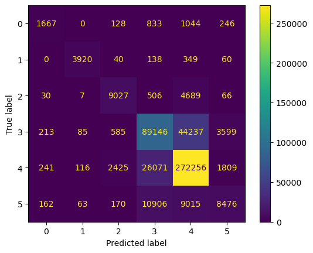

```python
# Confusion Matrix
cm = confusion_matrix(testy, y_pred_rf)
ConfusionMatrixDisplay(cm).plot()
```

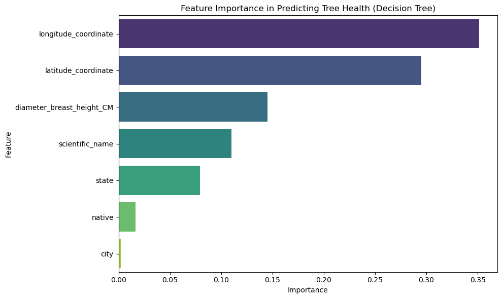

```python
### FEATURE IMPORTANCE ###
feature_names = X.columns
feature_dt = pd.DataFrame({'Feature': feature_names, 'Importance': dt.feature_importances_}).sort_values(by='Importance', ascending=False)

# Plot
plt.figure(figsize=(10, 6))
sns.barplot(data=feature_dt, x='Importance', y='Feature', palette='viridis')
plt.title("Feature Importance in Predicting Tree Health (Decision Tree)")
plt.tight_layout()
plt.show()
```

```python
### CROSS VALIDATION ###
# (stopped at 45min runtime)

models = {
    'Random Forest': rf,
    'KNN': kn,
    'Decision Tree': dt,
    'Logistic Regression': lr
}

print("\nCross-Validated Accuracy (5-fold):")
for name, model in models.items():
    scores = cross_val_score(model, X, y, cv=5, scoring='accuracy')
    print(f"{name}: {scores.mean():.3f}")
```

[output not shown]

```
Cross-Validated Accuracy (5-fold):
```

## Does City Carbon Emissions Matter?

Here we introduce carbon emissions data from PANGAEA data publisher to our current dataset. Note that all data introduced from this point forward is dated 2017 as this is the most common inventory date in our original tree data.

A classification report shows Random Forest exceled at identifying trees in good and dying trees but was less efficient at recall with trees in dead and poor condition. It was found that carbon emissions is not strongly predictive of tree condition at a city level. This is supported by visual comparison of the highest and lowest emission city tree condition spread.

```python
# TREE CONDITION AND CARBON EMISSIONS (SUBSET)

coemissions = pd.read_csv('coemissions.csv')
coemissions = coemissions.rename(columns={'City': 'city'})
coemissions = coemissions.rename(columns={'Total emissions (metric tonnes CO2e)': 'emissions'})

treeco = pd.merge(treecondition, coemissions[['city', 'emissions']], on='city', how='left').dropna()
```

```python
df = treeco.copy()
df = df[df['condition'] != ' ']
encoders = {}

# encode categorical
cat_cols = df.select_dtypes(include=['object']).columns
for col in cat_cols:
    le = LabelEncoder()
    df[col] = le.fit_transform(df[col])
    encoders[col] = le

reverse_lookup = {0: "dead", 1: "dead/dying", 2: "excellent", 3: "fair", 4: "good", 5: "poor"}
desired_order = {"dead": 0, "dead/dying": 1, "poor": 2, "fair": 3, "good": 4, "excellent": 5}

treeco2 = df.copy()
treeco2.loc[:, "condition_label"] = treeco2["condition"].map(reverse_lookup)
treeco2.loc[:, "conditionn"] = treeco2["condition_label"].map(desired_order)
treeco2[["condition", "condition_label", "conditionn"]].head(5)
```

|  | condition | condition_label | conditionn |
| --- | --- | --- | --- |
| 0 | 5 | poor | 2 |
| 1 | 3 | fair | 3 |
| 2 | 5 | poor | 2 |
| 3 | 5 | poor | 2 |
| 4 | 3 | fair | 3 |

```python
treeco2 = treeco2.drop(columns=['condition'])
```

```python
df = treeco2.copy() # Total emissions (metric tonnes CO2e)
print(' "dead": 0, "dead/dying": 1, "poor": 2, "fair": 3, "good": 4, "excellent": 5  ')

# split data
X = df.drop(columns=['conditionn', 'condition_label'])
y = df['conditionn']
trainX, testX, trainy, testy = train_test_split(X, y)

# classification
rf = RandomForestClassifier()
rf.fit(trainX, trainy)
y_pred = rf.predict(testX)
print(classification_report(testy, y_pred))
```

```
 "dead": 0, "dead/dying": 1, "poor": 2, "fair": 3, "good": 4, "excellent": 5
              precision    recall  f1-score   support

           0       0.74      0.47      0.58      1057
           1       0.95      0.87      0.90      4570
           2       0.77      0.54      0.64      9706
           3       0.74      0.73      0.74     32194
           4       0.86      0.92      0.89     76175
           5       0.77      0.67      0.72      6139

    accuracy                           0.83    129841
   macro avg       0.81      0.70      0.74    129841
weighted avg       0.82      0.83      0.82    129841
```

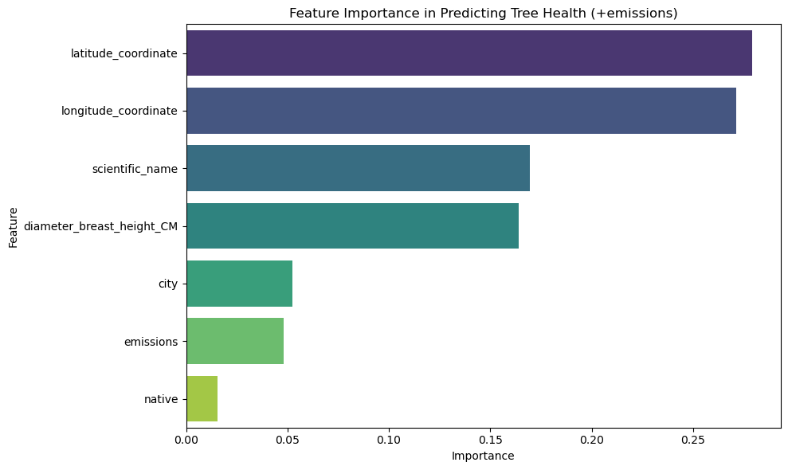

```python
### FEATURE IMPORTANCE ###
feature_names = X.columns
feature_rf = pd.DataFrame({'Feature': feature_names, 'Importance': rf.feature_importances_}).sort_values(by='Importance', ascending=False)

# Plot
plt.figure(figsize=(10, 6))
sns.barplot(data=feature_rf, x='Importance', y='Feature', palette='viridis')
plt.title("Feature Importance in Predicting Tree Health (+emissions)")
plt.tight_layout()
plt.show()
```

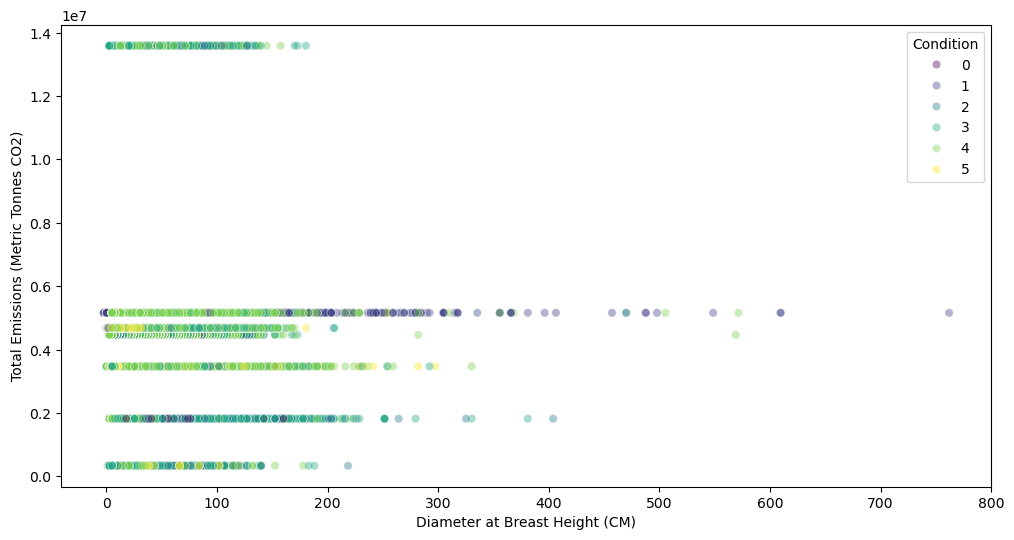

```python
### VISUAL ###
treeco3 = treeco2[(treeco2["diameter_breast_height_CM"] < 800)]

plt.figure(figsize=(12, 6))
sns.scatterplot(x = treeco3['diameter_breast_height_CM'],
                y = treeco3['emissions'], hue=treeco3['conditionn'], alpha=0.4,  palette="viridis")
plt.xlabel("Diameter at Breast Height (CM)")
plt.ylabel("Total Emissions (Metric Tonnes CO2)")
plt.legend(title="Condition")
plt.show()
```

```python
treeco2.groupby("city")["emissions"].sum().sort_values()
# 0: Austin
# 1: Columbus
# 6: Seattle
# 3: Greensboro
# 5: Minneapolis
# 4: Knoxville
# 2: Durhamm
```

```
city
4    2.750935e+09
3    1.685660e+10
2    7.493532e+10
0    8.015498e+10
1    2.460066e+11
6    5.601569e+11
5    9.747819e+11
Name: emissions, dtype: float64
```

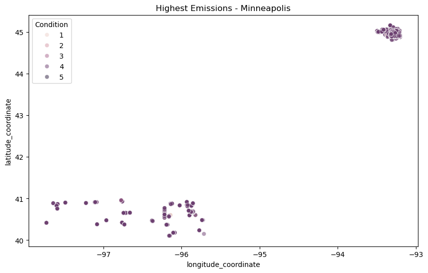

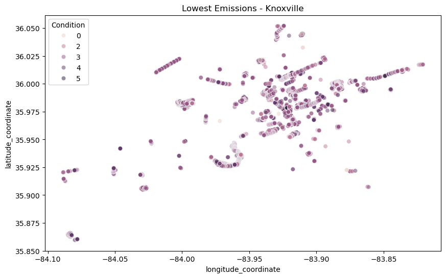

```python
df_low = treeco2[treeco2["city"] == 4]
df_high = treeco2[treeco2["city"] == 5]

# highest total emission - 188876
plt.figure(figsize=(10, 6))
sns.scatterplot(data = df_high, x = df_high['longitude_coordinate'],
                y = df_high['latitude_coordinate'], hue=df_high['conditionn'], alpha=0.5)
plt.title("Highest Emissions - Minneapolis")
plt.legend(title="Condition")
plt.show()

# lowest total emission - 8195
plt.figure(figsize=(10, 6))
sns.scatterplot(data = df_low, x = df_low['longitude_coordinate'],
                y = df_low['latitude_coordinate'], hue=df_low['conditionn'], alpha=0.5)
plt.title("Lowest Emissions - Knoxville")
plt.legend(title="Condition")
plt.show()
```

## How About Air Quality?

As CO2 intuitively is not a great predictor of tree health for several reasons. Trees do well in high CO2 environments but this is only a small attribute to a tree's prosperity, and high carbon emission may suggest presence of other pollutants in the air. Therefore, it would be better to look at air quality directly. This 2017 annual summary of air quality is sourced from U.S. Environmental Protection Agency. It is matched by city here. The two pollutants taken into account are defined:

PM2.5 (Particle Matter <= 2.5 micro meters)

- micrograms per cubic meter
- less than 12 -> good
- 12-35 -> moderate to unhealthy
- 35+ -> hazardous

Ozone (O3)

- parts per million (ppm) as an average over 8 hours
- less than .05 -> good
- 0.05-0.07 -> moderate
- 0.07+ -> unhealthy

```python
air_quality_df = pd.read_csv("/Users/millerchristen/Downloads/annual_conc_by_monitor_2017.csv")

# filter for PM2.5 and Ozone
filtered_aq = air_quality_df[air_quality_df['Parameter Code'].isin([88101, 44201])]
filtered_aq = filtered_aq[['City Name', 'State Name', 'Parameter Code', 'Arithmetic Mean']]

# calculate means of pollutants for each city
meanair = filtered_aq.pivot_table(
    index=['City Name', 'State Name'],
    columns='Parameter Code',
    values='Arithmetic Mean',
    aggfunc='mean'
).reset_index()

# rename parameters city/state to match
meanair.columns.name = None
meanair.rename(columns={88101: 'PM25', 44201: 'Ozone'}, inplace=True)
# rename city/state to match
meanair = meanair.rename(columns={
    'City Name': 'city',
    'State Name': 'state'
    })

meanair.head()
```

|  | city | state | Ozone | PM25 |
| --- | --- | --- | --- | --- |
| 0 | Aberdeen | South Dakota | NaN | 5.677596 |
| 1 | Adjuntas | Puerto Rico | NaN | 7.874468 |
| 2 | Air Force Academy | Colorado | 0.048142 | NaN |
| 3 | Akron | Ohio | 0.042613 | 8.491853 |
| 4 | Albany | Georgia | NaN | 9.717832 |

```python
treecondair = pd.merge(treecondition, meanair, on=['city', 'state'], how='left')
treecondair.head()
```

|  | condition | native | diameter_breast_height_CM | city | state | longitude_coordinate | latitude_coordinate | scientific_name | Ozone | PM25 |
| --- | --- | --- | --- | --- | --- | --- | --- | --- | --- | --- |
| 0 | poor | naturally_occurring | 68.58 | Austin | Texas | -97.736905 | 30.273151 | Quercus fusiformis | 0.042891 | 9.539558 |
| 1 | fair | naturally_occurring | 55.88 | Austin | Texas | -97.736577 | 30.273910 | Ulmus americana | 0.042891 | 9.539558 |
| 2 | poor | naturally_occurring | 86.36 | Austin | Texas | -97.736597 | 30.273360 | Quercus fusiformis | 0.042891 | 9.539558 |
| 3 | poor | naturally_occurring | 76.20 | Austin | Texas | -97.736319 | 30.273816 | Carya illinoinensis | 0.042891 | 9.539558 |
| 4 | fair | naturally_occurring | 50.80 | Austin | Texas | -97.736167 | 30.273598 | Quercus virginiana | 0.042891 | 9.539558 |

```python
treecondair = treecondair[treecondair['condition'] != ' ']
treecondair['condition'].unique()
encoders = {}

# encode categorical
cat_cols = treecondair.select_dtypes(include=['object']).columns
for col in cat_cols:
    le = LabelEncoder()
    treecondair[col] = le.fit_transform(treecondair[col])
    encoders[col] = le
treecondair['condition'].unique()
```

```
array([5, 3, 4, 2, 0, 1])
```

```python
# split data
X = treecondair.drop(columns=['condition'])
y = treecondair['condition']
trainX, testX, trainy, testy = train_test_split(X, y)

# classification
rf = RandomForestClassifier()
rf.fit(trainX, trainy)
y_pred = rf.predict(testX)
print(classification_report(testy, y_pred))
```

```
              precision    recall  f1-score   support

           0       0.71      0.43      0.53      3852
           1       0.94      0.86      0.90      4464
           2       0.74      0.64      0.68     14311
           3       0.70      0.65      0.67    137857
           4       0.82      0.90      0.86    302935
           5       0.60      0.30      0.40     28906

    accuracy                           0.78    492325
   macro avg       0.75      0.63      0.67    492325
weighted avg       0.77      0.78      0.77    492325
```

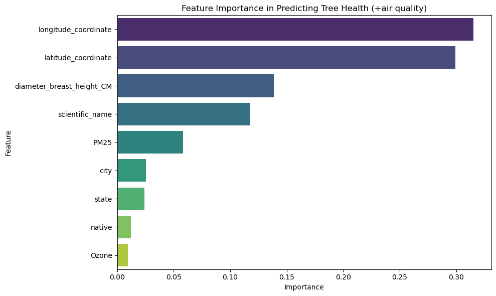

```python
### FEATURE IMPORTANCE ###
feature_names = X.columns
feature_rf = pd.DataFrame({'Feature': feature_names, 'Importance': rf.feature_importances_}).sort_values(by='Importance', ascending=False)

# Plot
plt.figure(figsize=(10, 6))
sns.barplot(data=feature_rf, x='Importance', y='Feature', palette='viridis')
plt.title("Feature Importance in Predicting Tree Health (+air quality)")
plt.tight_layout()
plt.show()
```

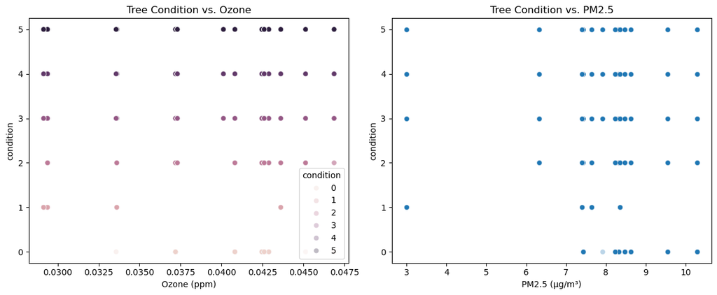

```python
fig, axs = plt.subplots(1, 2, figsize=(12, 5))

sns.scatterplot(data=treecondair, x='Ozone', y='condition',
                hue=treecondair['condition'], alpha=0.3, ax=axs[0])
axs[0].set_title("Tree Condition vs. Ozone")
axs[0].set_xlabel("Ozone (ppm)")

sns.scatterplot(data=treecondair, x='PM25', y='condition', alpha=0.3, ax=axs[1])
axs[1].set_title("Tree Condition vs. PM2.5")
axs[1].set_xlabel("PM2.5 (µg/m³)")

plt.tight_layout()
plt.show()
```

## Other

### Spatial Dependence

No output due to consistent kernel dying. Can use in future work. Global Moran's I will indicate if tree condition is spatially correlated overall. Local Moran's I can identify specific clusters of poor tree condition (hot spots).

```python
treespace = treecondition.copy()
treespace['city'].unique()
```

```
array(['Austin', 'Seattle', 'Aurora', 'New York', 'Greensboro',
       'St. Louis', 'Minneapolis', 'Columbus', 'Knoxville', 'Kailua',
       'Kaneohe', 'Honolulu', 'Waipahu', 'Ahuimanu', 'Heeia', 'Portland',
       'San Jose', 'Louisville', 'Durham', 'Washington DC', 'Sioux Falls'],
      dtype=object)
```

```python
# Do trees in healthy zones tend to be healthy?

city_name = "New York"
treespace = treespace[treespace['city'] == city_name].copy()
treespace['condition'] = pd.to_numeric(treespace['condition'], errors='coerce')

treespace['geometry'] = [Point(xy) for xy in zip(treespace['longitude_coordinate'], treespace['latitude_coordinate'])]
gdf = gpd.GeoDataFrame(treespace, geometry='geometry')

# weights
w = KNN.from_dataframe(gdf, k=5) # five nearest neighbors
w.transform = 'r'

# Global Moran's I
y = treespace['condition'].values
moran = Moran(y, w)
print(f"Moran's I: {moran.I:.4f}, simulated p-value: {moran.p_sim:.4f}")

# Local Moran's I (cluster detection)
m_local = Moran_Local(y, w)
treespace['local_cluster'] = (m_local.q == 1).astype(int)
```

```
Moran's I: nan, simulated p-value: 0.0010
```

[output not shown]

### Native Trees & Clustering

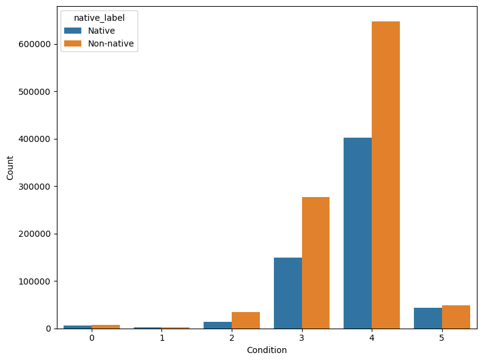

[figure not shown]

```python
### VISUAL ###

df = treecondition_encoded.copy()

df['native_label'] = df['native'].map({0: 'Non-native', 1: 'Native'})
counts = df.groupby(['native_label', 'condition']).size().reset_index(name='count')
counts['proportion'] = counts.groupby('native_label')['count'].transform(lambda x: x / x.sum())

# counts
plt.figure(figsize=(8, 6))
sns.barplot(data=counts, x='condition', y='count', hue='native_label')
plt.ylabel("Count")
plt.xlabel("Condition")
plt.tight_layout()
plt.show()

# create binary system (healthy = excellent, good, fair)
# class order: 'dead', 'dead/dying', 'excellent', 'fair', 'good', 'poor'
df = treecondition_encoded.copy()
df['healthy'] = df['condition'].isin([2, 4]).astype(int)
counts = df.groupby(['native_label', 'healthy']).size().reset_index(name='count')
counts['proportion'] = counts.groupby('native_label')['count'].transform(lambda x: x / x.sum())

# relative frequency within each native label group
plt.figure(figsize=(8, 6))
sns.barplot(data=counts, x='healthy', y='proportion', hue='native_label')
plt.ylabel("Proportion")
plt.xlabel("Healthy")
plt.tight_layout()
plt.show()
```

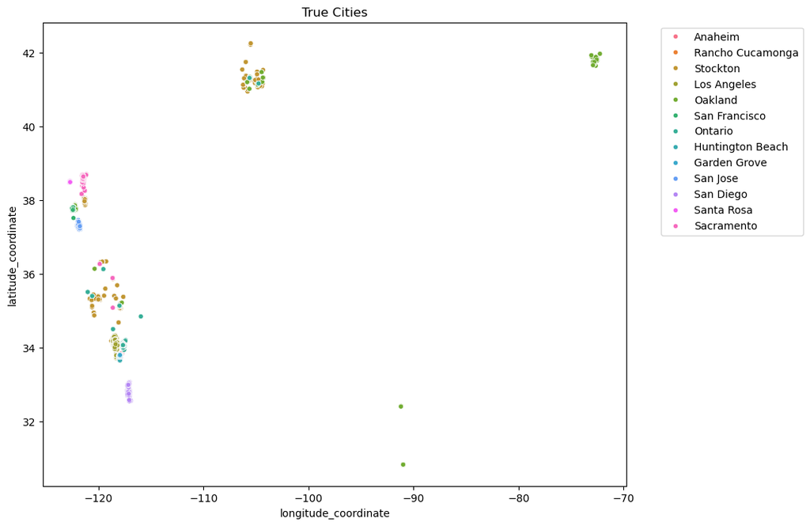

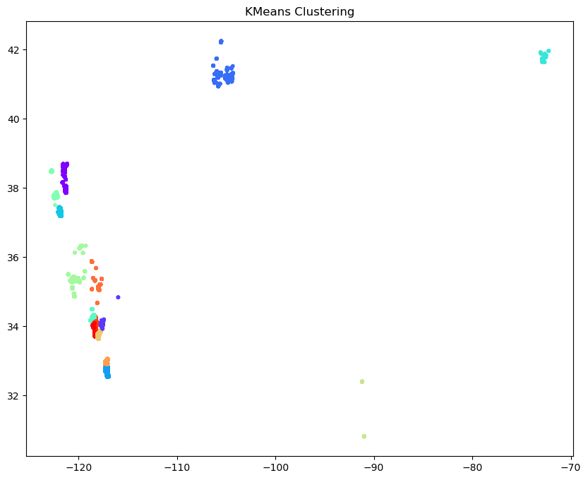

```python
### K MEAN CLUSTERING CALIFORNIA ###

california_shp = gpd.read_file('/Users/millerchristen/Downloads/tl_2024_06_tabblock20/tl_2024_06_tabblock20.shp')
california = citytrees[citytrees['state'] == 'California']

# True Cities
fig, ax = plt.subplots(figsize=(10, 8))
# california_shp.plot(ax=ax, color='none', edgecolor='black')
sns.scatterplot(x=california['longitude_coordinate'], y=california['latitude_coordinate'], s=20, hue=california['city'], ax=ax)
plt.title("True Cities")
plt.legend(bbox_to_anchor=(1.05, 1.0), loc='upper left')
plt.show()

# Kmeans
X = np.array(list(zip(california['longitude_coordinate'], california['latitude_coordinate'])))
est = KMeans(15) # 15 cities
est.fit(X)
y_kmeans = est.predict(X)

fig, ax = plt.subplots(figsize=(10, 8))
# california_shp.plot(ax=ax, color='none', edgecolor='black')
scatter = ax.scatter(X[:, 0], X[:, 1], s=10, c=y_kmeans, cmap='rainbow')
plt.title("KMeans Clustering")
plt.show()
```

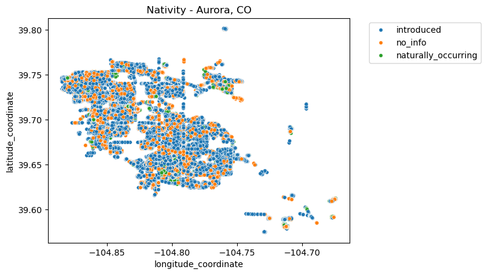

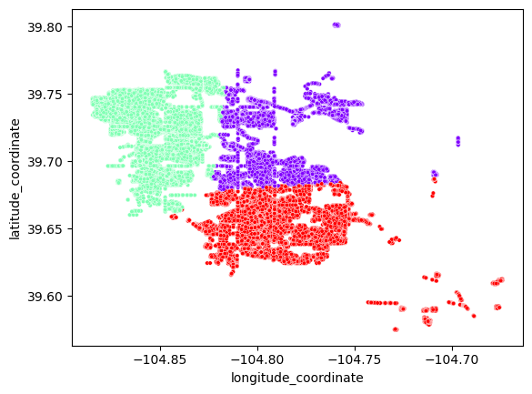

```python
### CLUSTERING NATIVITY ###

city = aurora
hue = 'native'

#  True
plt.figsize=(10, 8)
sns.scatterplot(x=city['longitude_coordinate'], y=city['latitude_coordinate'], s=20, hue=city[hue])
plt.legend(bbox_to_anchor=(1.05, 1.0), loc='upper left')
plt.title("Nativity - Aurora, CO")
plt.show()

# Kmeans
X = np.array(list(zip(city['longitude_coordinate'], city['latitude_coordinate'])))
est = KMeans(n_clusters=3)
est.fit(X)
y_kmeans = est.predict(X)

plt.figsize=(10, 8)
sns.scatterplot(x=city['longitude_coordinate'], y=city['latitude_coordinate'], s=10, c=y_kmeans, cmap='rainbow')
plt.show()
```

### Hawaiian Urban Forests

```python
treehealth = pd.read_csv('/Users/millerchristen/Desktop/STAT 531/suplementary files/treehealth.csv')
treehealth.head()
```

|  | index | condition | native | height_M | diameter_CM | city | state | longitude_coordinate | latitude_coordinate | scientific_name |
| --- | --- | --- | --- | --- | --- | --- | --- | --- | --- | --- |
| 0 | 332837 | poor | naturally_occurring | 88.58268 | 68.58 | Austin | Texas | -97.736905 | 30.273151 | Quercus fusiformis |
| 1 | 332838 | fair | naturally_occurring | 26.24672 | 55.88 | Austin | Texas | -97.736577 | 30.273910 | Ulmus americana |
| 2 | 332839 | poor | naturally_occurring | 98.42520 | 86.36 | Austin | Texas | -97.736597 | 30.273360 | Quercus fusiformis |
| 3 | 332840 | poor | naturally_occurring | 26.24672 | 76.20 | Austin | Texas | -97.736319 | 30.273816 | Carya illinoinensis |
| 4 | 332841 | fair | naturally_occurring | 26.24672 | 50.80 | Austin | Texas | -97.736167 | 30.273598 | Quercus virginiana |

```python
# treehealth[treehealth["state"] == "California"] # only San Jose
hawaii_th = treehealth[treehealth["state"] == "Hawaii"]
hawaii_th['city'].unique()
```

```
array(['Kailua', 'Kaneohe', 'Honolulu', 'Waipahu', 'Ahuimanu', 'Heeia'],
      dtype=object)
```

```python
# encode categorical variables
hawaii_th['native_encoded'] = LabelEncoder().fit_transform(hawaii_th['native'])
hawaii_th['city_encoded'] = LabelEncoder().fit_transform(hawaii_th['city'])
hawaii_th['species'] = LabelEncoder().fit_transform(hawaii_th['scientific_name'])
```

```python
hawaii_th['condition'].value_counts()
```

```
condition
good          12864
fair           1051
poor            248
dead/dying       64
Name: count, dtype: int64
```

```python
# create binary for condition (healthy (1): good, fair & unhealthy (0): poor, dead/dying)
hawaii_th['healthy'] = hawaii_th['condition'].isin(['good', 'fair']).astype(int)
hawaii_th['healthy'].value_counts()
```

```
healthy
1    13915
0      312
Name: count, dtype: int64
```

```python
hawaii_th.head()
```

|  | index | condition | native | height_M | diameter_CM | city | state | longitude_coordinate | latitude_coordinate | scientific_name | native_encoded | city_encoded | species | healthy |
| --- | --- | --- | --- | --- | --- | --- | --- | --- | --- | --- | --- | --- | --- | --- |
| 8603 | 3530034 | poor | introduced | 39.37008 | 0.0 | Kailua | Hawaii | -157.730577 | 21.370081 | Conocarpus erectus | 0 | 3 | 70 | 0 |
| 8604 | 3530037 | poor | introduced | 19.68504 | 0.0 | Kaneohe | Hawaii | -157.784277 | 21.404992 | Azadirachta indica | 0 | 4 | 23 | 0 |
| 8605 | 3530039 | good | introduced | 16.40420 | 0.0 | Kailua | Hawaii | -157.729755 | 21.381286 | Citrus limon | 0 | 3 | 61 | 1 |
| 8606 | 3530040 | good | introduced | 68.89764 | 0.0 | Honolulu | Hawaii | -157.823790 | 21.304216 | Cassia fistula | 0 | 2 | 45 | 1 |
| 8607 | 3530043 | dead/dying | introduced | 0.00000 | 0.0 | Honolulu | Hawaii | -157.847650 | 21.285250 | Cocos nucifera | 0 | 2 | 68 | 0 |

```python
### CLASSIFICATION (HEALTH) ###

# split data
X = hawaii_th[['diameter_CM', 'height_M', 'longitude_coordinate', 'latitude_coordinate', 'native_encoded', 'city_encoded', 'species']]
y = hawaii_th['healthy']
trainX, testX, trainy, testy = train_test_split(X, y, test_size=0.2, random_state=42)

# Logistic GAM
gam = LogisticGAM(
    s(0) + s(1) + s(2) + s(3) + f(4) + f(5) + f(6)
    ).fit(trainX, trainy)
print(f"GAM Accuracy: {accuracy_score(testy, gam.predict(testX)):.3f}")

# Random Forest
rf = RandomForestClassifier(n_estimators=100, random_state=42)
rf.fit(trainX, trainy)
rf_pred = rf.predict(testX)
print(f"Classification Report: \n {classification_report(testy, rf_pred)}")
```

```
GAM Accuracy: 0.976
Classification Report:
               precision    recall  f1-score   support

           0       1.00      0.12      0.21        68
           1       0.98      1.00      0.99      2778

    accuracy                           0.98      2846
   macro avg       0.99      0.56      0.60      2846
weighted avg       0.98      0.98      0.97      2846
```

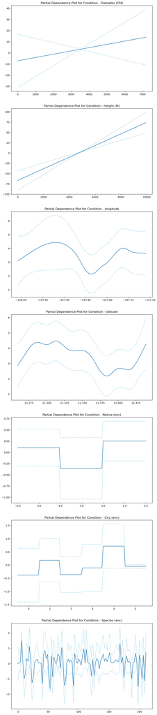

```python
# plot partial depedence and CI bounds
fig, axs = plt.subplots(7, 1, figsize=(10, 50))
fig = plt.figure()

titles = ['Diameter (CM)', 'Height (M)', 'longitude', 'latitude', 'Native (enc)', 'City (enc)', 'Species (enc)']

for i, ax in enumerate(axs):
    XX = gam.generate_X_grid(term=i)
    pdep, confi = gam.partial_dependence(term=i, width=0.95)
    ax.plot(XX[:, i], pdep)
    ax.plot(XX[:, i], confi[:, 0], ls='--', color='lightblue', label="95% CI")
    ax.plot(XX[:, i], confi[:, 1], ls='--', color='lightblue')
    ax.set_title(f'Partial Dependence Plot for Condition - {titles[i]}')

plt.tight_layout()
plt.show()
```

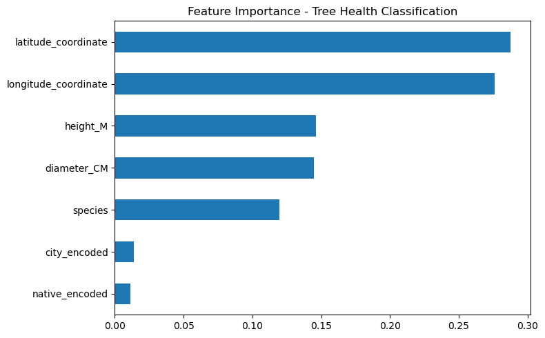

```python
# Feature importance from Random Forest
importances = pd.Series(rf.feature_importances_, index=X.columns)
importances.sort_values().plot(kind='barh', figsize=(8,5),
                               title="Feature Importance - Tree Health Classification")
plt.tight_layout()
plt.show()
```

```python
### REGRESSION (HEIGHT) ###
filtered_df = hawaii_th[hawaii_th['height_M'] < 500].copy()

# split data
X_reg = filtered_df[['diameter_CM', 'longitude_coordinate', 'latitude_coordinate', 'native_encoded', 'species', 'healthy']]
y_reg = filtered_df['height_M']
trainX_r, testX_r, trainy_r, testy_r = train_test_split(X_reg, y_reg, test_size=0.2, random_state=42)
```

```
Ridge R²: 0.089, RMSE: 48.25
```

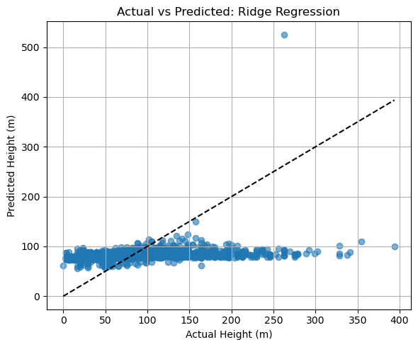

```python
# Ridge Regression
ridge = Ridge(alpha=5.0)
ridge.fit(trainX_r, trainy_r)
ridge_pred = ridge.predict(testX_r)
print(f"Ridge R²: {r2_score(testy_r, ridge_pred):.3f}, RMSE: {np.sqrt(mean_squared_error(testy_r, ridge_pred)):.2f}")

# Plot: Actual vs Predicted for Ridge
plt.figure(figsize=(6,5))
plt.scatter(testy_r, ridge_pred, alpha=0.6)
plt.plot([testy_r.min(), testy_r.max()], [testy_r.min(), testy_r.max()], 'k--')
plt.xlabel("Actual Height (m)")
plt.ylabel("Predicted Height (m)")
plt.title("Actual vs Predicted: Ridge Regression")
plt.grid(True)
plt.tight_layout()
plt.show()
```

```python
# find the outlier
high_pred = np.where(ridge_pred > 500)[0]
for idx in high_pred:
    print(f"Index: {idx}, Predicted: {ridge_pred[idx]:}, Actual: {testy_r.iloc[idx]:}")
```

```
Index: 1677, Predicted: 525.2972063003017, Actual: 262.4672
```

```
GAM R²: 0.638
```

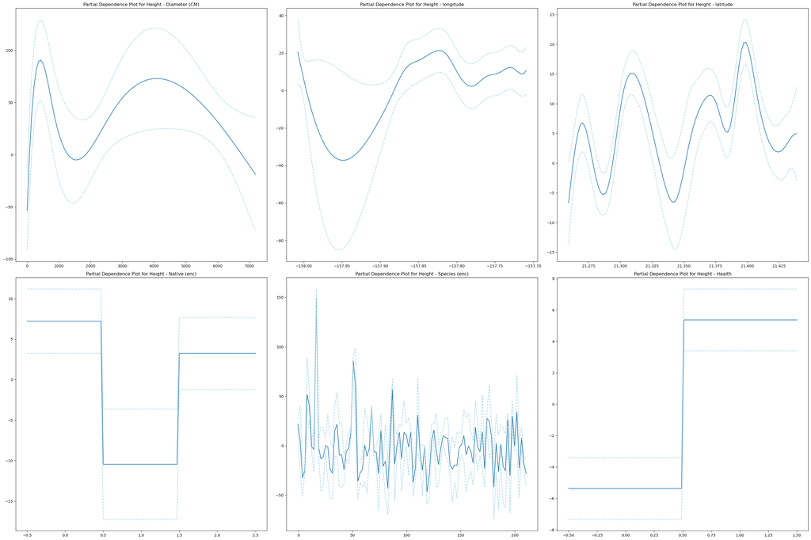

```python
# Linear GAM
gam_reg = LinearGAM(
    s(0) + s(1) + s(2) + f(3) + f(4) + f(5)
    ).fit(trainX_r, trainy_r)
print(f"GAM R²: {gam_reg.score(testX_r, testy_r):.3f}")

# plot partial depedence and CI bounds
fig, axs = plt.subplots(2, 3, figsize=(30, 20))
axs = axs.flatten()

titles = ['Diameter (CM)', 'longitude', 'latitude', 'Native (enc)', 'Species (enc)', 'Health']

for i, ax in enumerate(axs):
    XX = gam_reg.generate_X_grid(term=i)
    pdep, confi = gam_reg.partial_dependence(term=i, width=0.95)
    ax.plot(XX[:, i], pdep)
    ax.plot(XX[:, i], confi[:, 0], ls='--', color='lightblue', label="95% CI")
    ax.plot(XX[:, i], confi[:, 1], ls='--', color='lightblue')
    ax.set_title(f'Partial Dependence Plot for Height - {titles[i]}')

plt.tight_layout()
plt.show()
```

```python
# Fit KNN
knn = KNeighborsRegressor(n_neighbors=5)
knn.fit(trainX_r, trainy_r)
pred_knn = knn.predict(testX_r)

r2_knn = r2_score(testy_r, pred_knn)
rmse_knn = np.sqrt(mean_squared_error(testy_r, pred_knn))
print(f"KNN R²: {r2_knn:.3f}, RMSE: {rmse_knn:.2f}")
```

```
KNN R²: 0.618, RMSE: 31.26
```

```python
# Fun Plot :)
import plotly.express as px

hawaiii = treehealth[treehealth["state"] == "Hawaii"]

fig = px.scatter_mapbox(hawaiii, lon='longitude_coordinate', lat='latitude_coordinate',
    color='scientific_name',
    hover_data=['diameter_CM', 'condition', 'native'],
    zoom=10, height=600,
    title="🌸 Hawaii Trees 🌸", labels={"scientific_name": "🌼 Tree Type"}
)
fig.update_layout(mapbox_style="carto-positron")
fig.update_layout(margin={"r":0,"t":50,"l":0,"b":0})
fig.show()
```

[output not shown]

## Citations

[1] McCoy, Dakota; Goulet-Scott, Benjamin; Meng, Weilin et al. (2022). A dataset of 5 million city trees from 63 US cities: species, location, nativity status, health, and more. [Dataset]. Dryad. https://doi.org/10.5061/dryad.2jm63xsrf

[2] Nangini, Cathy; Peregon, Anna; Ciais, Philippe; Weddige, Ulf; Vogel, Felix; Wang, Jun; Bréon, François-Marie; Bachra, Simeran; Wang, Yilong; Gurney, Kevin; Yamagata, Yoshiki; Appleby, Kyra; Telahoun, Sara; Canadell, Josep G; Grübler, Arnulf; Dhakal, Shobhakar; Creutzig, Felix (2017): CO2 emissions and ancillary data for 343 cities from diverse sources [dataset]. PANGAEA, https://doi.org/10.1594/PANGAEA.884141, Supplement to: Nangini, C et al. (2019): A global dataset of CO2 emissions and ancillary data related to emissions for 343 cities. Scientific Data, 6, 180280, https://doi.org/10.1038/sdata.2018.280

[3] U.S. Environmental Protection Agency. Air Quality System Data Mart. Available via https://www.epa.gov/outdoor-air-quality-data.